# Prediction Assignment Writeup

ENA

November 18, 2017

## Overview

Using devices such as Jawbone Up, Nike FuelBand, and Fitbit it is now possible to collect a large amount of data about personal activity relatively inexpensively. These type of devices are part of the quantified self movement - a group of enthusiasts who take measurements about themselves regularly to improve their health, to find patterns in their behavior, or because they are tech geeks. One thing that people regularly do is quantify how much of a particular activity they do, but they rarely quantify how well they do it. In this project, your goal will be to use data from accelerometers on the belt, forearm, arm, and dumbell of 6 participants. They were asked to perform barbell lifts correctly and incorrectly in 5 different ways. More information is available from the website here: http://groupware.les.inf.puc-rio.br/har (see the section on the Weight Lifting Exercise Dataset).

The data for this project come from this source: http://groupware.les.inf.puc-rio.br/har.

The goal of your project is to predict the manner in which they did the exercise. This is the “classe” variable in the training set. You may use any of the other variables to predict with. You should create a report describing how you built your model, how you used cross validation, what you think the expected out of sample error is, and why you made the choices you did. You will also use your prediction model to predict 20 different test cases.

## Data Pre-Processing

Read the training and testingdata from the CSV files. Remove the columns with with ‘NA’ values. Remove the columns that represent the row number, timestamps and num_window. Bisides classe we want the rest of the data to be numeric. Apply the transformations bth for training and testing sets.

```r
training <- read.csv('C:\\DataScience\\pml-training.csv')
testing <- read.csv('C:\\DataScience\\pml-testing.csv')

#keep classe column for futur use; it's values are A B C D E, non-numeric
classe <- training$classe
#get only the columns without missing values
training <- training[, colSums(is.na(training)) == 0]
#remove non-numeric columns
training <- training[, sapply(training, is.numeric)]
#remove unnecessary columns like row number, time stamps and num_window
training <- training[, !grepl("^X|timestamp|window", names(training))]
#add classe back to the data set (the rest of the data is numeric)
training$classe <- classe

#remove unnecessary columns from the testing set
testing <- testing[, colSums(is.na(testing)) == 0]
testing  <- testing[, sapply(testing, is.numeric)]
testing <- testing[, !grepl("^X|timestamp|window", names(testing))]
```

After the clean up the trainng data set hs 19622 records with 53 variables one of which is classe.

## Data Splitting

Set the seed and split the training data set with p=3/4 using classe variable.

```r
#set the seed
set.seed(12345)
#split the data
trainIdx <- createDataPartition(y = training$classe, list = FALSE, p=3/4)
trainData <- training[trainIdx,]
testData <- training[-trainIdx,]
```

## Model Training and Tuning

Caret package train function was used to evaluate the resampling and the effect of model tuning parameters on performance; choose the “optimal” model across these parameters; estimate model performance from a training set.

For this project we decided to use random forest because it uses a random sample of the data training each tree independently. This randomnes helps to make the model more robust than a single decision tree and less likely to overfit on the training data.

The function trainControl was used to specifiy the type of resampling, cv, with 4-fold cross-validations that are used as the resampling scheme for bootstrapping.

```r
#generating parametes that later are going to be used; resampling parameter cv.
fitControl <- trainControl(method="cv",
                           4)

#random forest model
rfFit <- train(classe ~ .,
                 data=trainData,
                 method="rf",
                 trControl=fitControl,
                 ntree=200)
#see the outcome
rfFit
```

```
## Random Forest
##
## 14718 samples
##    52 predictor
##     5 classes: 'A', 'B', 'C', 'D', 'E'
##
## No pre-processing
## Resampling: Cross-Validated (4 fold)
## Summary of sample sizes: 11040, 11038, 11038, 11038
## Resampling results across tuning parameters:
##
##   mtry  Accuracy   Kappa
##    2    0.9907592  0.9883090
##   27    0.9912350  0.9889118
##   52    0.9874304  0.9840969
##
## Accuracy was used to select the optimal model using  the largest value.
## The final value used for the model was mtry = 27.
```

## Model Evaluation

Pedict the outcomes on the test dataset uing Caret package function predict. Evaluate the acuracy of the model we built.

```r
#apply the model to the test data set
modelprediction <- predict(rfFit, testData)
#see the confusion matrix
confusionMatrix(testData$classe, modelprediction)
```

```
## Confusion Matrix and Statistics
##
##           Reference
## Prediction    A    B    C    D    E
##          A 1393    2    0    0    0
##          B    8  936    5    0    0
##          C    0    2  849    4    0
##          D    0    0   10  794    0
##          E    0    0    2    5  894
##
## Overall Statistics
##
##                Accuracy : 0.9923
##                  95% CI : (0.9894, 0.9945)
##     No Information Rate : 0.2857
##     P-Value [Acc > NIR] : < 2.2e-16
##
##                   Kappa : 0.9902
##  Mcnemar's Test P-Value : NA
##
## Statistics by Class:
##
##                      Class: A Class: B Class: C Class: D Class: E
## Sensitivity            0.9943   0.9957   0.9804   0.9888   1.0000
## Specificity            0.9994   0.9967   0.9985   0.9976   0.9983
## Pos Pred Value         0.9986   0.9863   0.9930   0.9876   0.9922
## Neg Pred Value         0.9977   0.9990   0.9958   0.9978   1.0000
## Prevalence             0.2857   0.1917   0.1766   0.1637   0.1823
## Detection Rate         0.2841   0.1909   0.1731   0.1619   0.1823
## Detection Prevalence   0.2845   0.1935   0.1743   0.1639   0.1837
## Balanced Accuracy      0.9969   0.9962   0.9894   0.9932   0.9991
```

```r
#check out the model acuracy
modelaccuracy <- postResample(modelprediction, testData$classe)
#review the acuracy
modelaccuracy
```

```
##  Accuracy     Kappa
## 0.9922512 0.9901978
```

Our model has 99% accuracy. It predicts sensitivity and specificity for each classe with over 98% accuracy.

## Apply the prediction on the provided test dataset with the 20 test cases

```
##  [1] B A B A A E D B A A B C B A E E A B B B
## Levels: A B C D E
```

# Appendix

Decision Tree Visualization

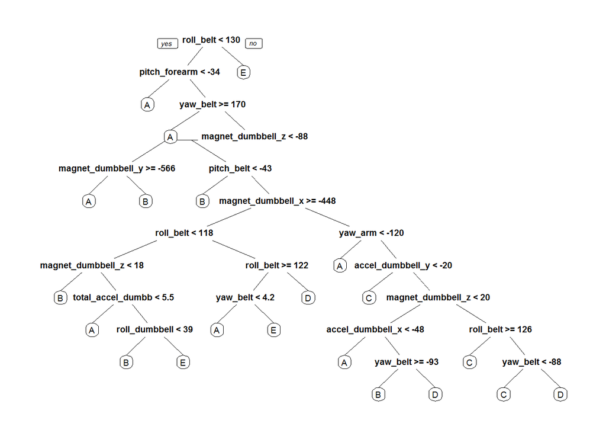

```r
treeModel <- rpart(classe ~ ., data=trainData, method="class")
prp(treeModel)
```

Correlation Matrix Visualization

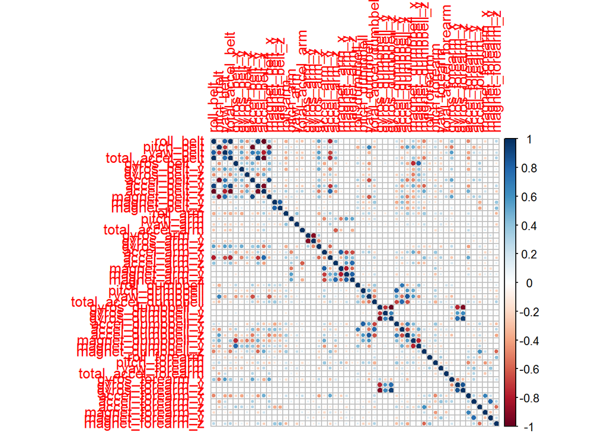

```r
corrPlot <- cor(trainData[, -length(names(trainData))])
corrplot(corrPlot, method="circle")
```